# HW: Foundations of Inference in `R`

Elise Haylett

March 30, 2020 @ 02:07 AM

**DataCamp Course Link:** [Foundations of Inference](https://www.datacamp.com/courses/foundations-of-inference)

*One of the foundational aspects of statistical analysis is inference, or the process of drawing conclusions about a larger population from a sample of data. Although counter intuitive, the standard practice is to attempt to disprove a research claim that is not of interest. For example, to show that one medical treatment is better than another, we can assume that the two treatments lead to equal survival rates only to then be disproved by the data. Additionally, we introduce the idea of a p-value, or the degree of disagreement between the data and the hypothesis. We also dive into confidence intervals, which measure the magnitude of the effect of interest (e.g. how much better one treatment is than another).*

**Instructions**

> Replicate all of the activities from the DataCamp course *Foundations of Inference*, including the code and comments. For videos, summarize the main points. You are welcome to include additional text or comments of your own to help you recall the specifics of the lessons.

### Packages Used

```r
library(tidyverse)
library(infer)
library(NHANES) #includes NHANES dataset
```

### Datasets Used

```r
sex <- rep("male", 24)
promote <- c(rep("promoted", 21), rep("not_promoted", 3))
discmanual <- data.frame(promote, sex)

sex <- rep("female", 24)
promote <- c(rep("promoted", 14), rep("not_promoted", 10))
discmanual2 <- data.frame(promote, sex)

disc <- rbind(discmanual, discmanual2)
str(disc)
```

```
'data.frame':   48 obs. of  2 variables:
 $ promote: Factor w/ 2 levels "not_promoted",..: 2 2 2 2 2 2 2 2 2 2 ...
 $ sex    : Factor w/ 2 levels "male","female": 1 1 1 1 1 1 1 1 1 1 ...
```

```r
disc_new <- readRDS(gzcon(url("https://assets.datacamp.com/production/repositories/538/datasets/60566129b391ef827ea9c8a9846608dee24ce34a/disc_new.rds")))
str(disc_new)
```

```
'data.frame':   48 obs. of  2 variables:
 $ promote: Factor w/ 2 levels "not_promoted",..: 2 2 2 2 2 2 2 2 2 2 ...
 $ sex    : Factor w/ 2 levels "female","male": 2 2 2 2 2 2 2 2 2 2 ...
```

```r
disc_small <- readRDS(gzcon(url("https://assets.datacamp.com/production/repositories/538/datasets/543fa990550c61f6a2cc175b0a0414528f8094c0/disc_small.rds")))
str(disc_small)
```

```
'data.frame':   16 obs. of  2 variables:
 $ promote: Factor w/ 2 levels "not_promoted",..: 2 2 2 2 2 2 2 2 2 2 ...
 $ sex    : Factor w/ 2 levels "female","male": 2 2 2 2 2 2 2 1 1 1 ...
```

```r
disc_big <- readRDS(gzcon(url("https://assets.datacamp.com/production/repositories/538/datasets/f03da8fc4a2ae50a3ddf775324f4df90c96f7f26/disc_big.rds")))
str(disc_big)
```

```
'data.frame':   480 obs. of  2 variables:
 $ promote: Factor w/ 2 levels "not_promoted",..: 2 2 2 2 2 2 2 2 2 2 ...
 $ sex    : Factor w/ 2 levels "female","male": 2 2 2 2 2 2 2 2 2 2 ...
```

```r
opportunity <- tibble(decision = rep(c("buyDVD", "nobuyDVD"), c(97, 53)),
                      group = rep(rep(c("control", "treatment"), 2), c(56, 41, 19, 34)))
str(opportunity)
```

```
Classes 'tbl_df', 'tbl' and 'data.frame':   150 obs. of  2 variables:
 $ decision: chr  "buyDVD" "buyDVD" "buyDVD" "buyDVD" ...
 $ group   : chr  "control" "control" "control" "control" ...
```

```r
load(url("https://assets.datacamp.com/production/repositories/538/datasets/b1071ca5cb72143820e33fd7c6605dc4b3f11b7a/all_polls.RData"))
str(all_polls)
```

```
Classes 'tbl_df', 'tbl' and 'data.frame':   30000 obs. of  2 variables:
 $ poll: int  1 1 1 1 1 1 1 1 1 1 ...
 $ vote: chr  "no" "yes" "no" "no" ...
```

## ① Introduction to Ideas of Inference

### Welcome to the course!

VIDEO SUMMARY: We will now make inferential claims in addition to descriptive statistics with the data. Statistical inference is the process of making claims about a population based on information from a sample. The interest is the population. The claim that is not interesting is the null hypothesis ($H_0$). The claim that corresponds to the research hypothesis is the alternative hypothesis ($H_A$).

The **“goal”** is to disprove the null hypothesis and claim that the alternative hypothesis is true.

### Hypothesis (1)

Suppose a pharmaceutical company is trying to get FDA approval for a new diabetes treatment called drug A. Currently, most doctors prescribe drug B to treat diabetes.

Which would be a good *null* hypothesis for the FDA statistician examining the drug company’s data?

**NULL HYPOTHESIS: Drug A is the same as drug B at treating diabetes**

### Hypothesis (2)

Consider the same situation as in the last exercise. A pharmaceutical company is trying to pass drug A for diabetes through the FDA, but most doctors currently prescribe drug B.

Which would be a good *alternative* hypothesis?

**ALTERNATIVE HYPOTHESIS: Drug A is better than drug B at treating diabetes**

### Randomized distributions

VIDEO SUMMARY: The key to statistical inference is to understand samples from a hypothetical population where the $H_0$ is true. To summarize each of the null samples, we calulate one statistic from each sample. The difference in proportions, $\widehat{p}$, changes with each sample. We can build a distribution of differences in proportion assuming the null hypothesis is true. Generating a distribution of the statistic from the null population gives information about whether the observed data are inconsistent with the null hypothesis. The null samples consist of randomly shuffled variables so that the samples don’t have any dependency

#### Working with the NHANES data

**Note:** You do not need to reload `NHANES` and `ggplot` here.

```r
# Exercise 1

# What are the variables in the NHANES dataset?
colnames(NHANES)
```

```
 [1] "ID"               "SurveyYr"         "Gender"           "Age"
 [5] "AgeDecade"        "AgeMonths"        "Race1"            "Race3"
 [9] "Education"        "MaritalStatus"    "HHIncome"         "HHIncomeMid"
[13] "Poverty"          "HomeRooms"        "HomeOwn"          "Work"
[17] "Weight"           "Length"           "HeadCirc"         "Height"
[21] "BMI"              "BMICatUnder20yrs" "BMI_WHO"          "Pulse"
[25] "BPSysAve"         "BPDiaAve"         "BPSys1"           "BPDia1"
[29] "BPSys2"           "BPDia2"           "BPSys3"           "BPDia3"
[33] "Testosterone"     "DirectChol"       "TotChol"          "UrineVol1"
[37] "UrineFlow1"       "UrineVol2"        "UrineFlow2"       "Diabetes"
[41] "DiabetesAge"      "HealthGen"        "DaysPhysHlthBad"  "DaysMentHlthBad"
[45] "LittleInterest"   "Depressed"        "nPregnancies"     "nBabies"
[49] "Age1stBaby"       "SleepHrsNight"    "SleepTrouble"     "PhysActive"
[53] "PhysActiveDays"   "TVHrsDay"         "CompHrsDay"       "TVHrsDayChild"
[57] "CompHrsDayChild"  "Alcohol12PlusYr"  "AlcoholDay"       "AlcoholYear"
[61] "SmokeNow"         "Smoke100"         "Smoke100n"        "SmokeAge"
[65] "Marijuana"        "AgeFirstMarij"    "RegularMarij"     "AgeRegMarij"
[69] "HardDrugs"        "SexEver"          "SexAge"           "SexNumPartnLife"
[73] "SexNumPartYear"   "SameSex"          "SexOrientation"   "PregnantNow"
```

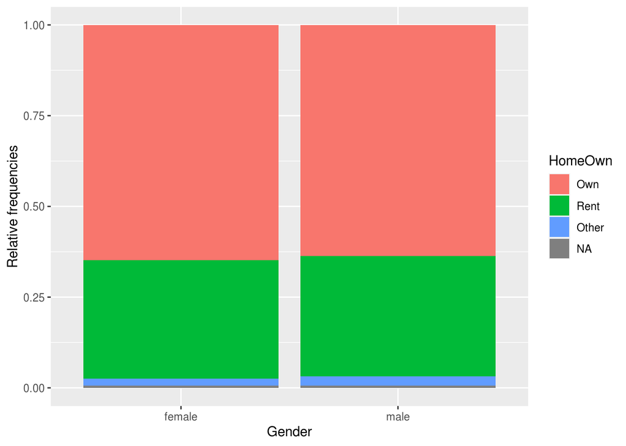

```r
# Exercise 2

# Create bar plot for Home Ownership by Gender
ggplot(NHANES, aes(x = Gender, fill = HomeOwn)) +
  # Set the position to fill
  geom_bar(position = "fill") +
  ylab("Relative frequencies")
```

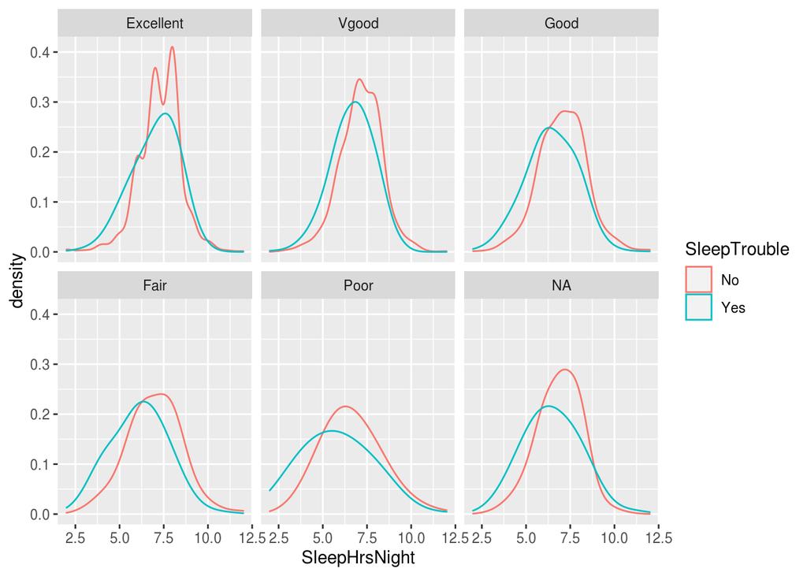

```r
# Exercise 3

# Density plot of SleepHrsNight colored by SleepTrouble
ggplot(NHANES, aes(x = SleepHrsNight, color = SleepTrouble)) +
  # Adjust by 2
  geom_density(adjust = 2) +
  # Facet by HealthGen
  facet_wrap(~ HealthGen)
```

#### Calculating the statistic of interest

```r
# Exercise 1
homes <- NHANES %>%
  # Select Gender and HomeOwn
  select(Gender, HomeOwn) %>%
  # Filter for HomeOwn equal to "Own" or "Rent"
  filter(HomeOwn %in% c("Own", "Rent"))
```

```r
# Exercise 2

# From previous step
homes <- NHANES %>%
  select(Gender, HomeOwn) %>%
  filter(HomeOwn %in% c("Own", "Rent"))

diff_orig <- homes %>%
  # Group by gender
  group_by(Gender) %>%
  # Summarize proportion of homeowners
  summarize(prop_own = mean(HomeOwn == "Own")) %>%
  # Summarize difference in proportion of homeowners
  summarize(obs_diff_prop = diff(prop_own)) # male - female

# See the result
diff_orig
```

```
# A tibble: 1 x 1
  obs_diff_prop
          <dbl>
1      -0.00783
```

#### Randomized data under null model of independence

```r
# Exercise 1

# Specify variables
homeown_perm <- homes %>%
  specify(HomeOwn ~ Gender, success = "Own")

# Print results to console
homeown_perm
```

```
Response: HomeOwn (factor)
Explanatory: Gender (factor)
# A tibble: 9,712 x 2
   HomeOwn Gender
   <fct>   <fct>
 1 Own     male
 2 Own     male
 3 Own     male
 4 Own     male
 5 Rent    female
 6 Rent    male
 7 Own     male
 8 Own     female
 9 Own     female
10 Own     female
# … with 9,702 more rows
```

```r
# Exercise 2

# Hypothesize independence
homeown_perm <- homes %>%
  specify(HomeOwn ~ Gender, success = "Own") %>%
  hypothesize(null = "independence")

# Print results to console
homeown_perm
```

```
Response: HomeOwn (factor)
Explanatory: Gender (factor)
Null Hypothesis: independence
# A tibble: 9,712 x 2
   HomeOwn Gender
   <fct>   <fct>
 1 Own     male
 2 Own     male
 3 Own     male
 4 Own     male
 5 Rent    female
 6 Rent    male
 7 Own     male
 8 Own     female
 9 Own     female
10 Own     female
# … with 9,702 more rows
```

```r
# Exercise 3

# Perform 10 permutations
homeown_perm <- homes %>%
  specify(HomeOwn ~ Gender, success = "Own") %>%
  hypothesize(null = "independence") %>%
  generate(reps = 10, type = "permute")

# Print results to console
homeown_perm
```

```
Response: HomeOwn (factor)
Explanatory: Gender (factor)
Null Hypothesis: independence
# A tibble: 97,120 x 3
# Groups:   replicate [10]
   HomeOwn Gender replicate
   <fct>   <fct>      <int>
 1 Rent    male           1
 2 Own     male           1
 3 Own     male           1
 4 Own     male           1
 5 Rent    female         1
 6 Rent    male           1
 7 Own     male           1
 8 Rent    female         1
 9 Own     female         1
10 Rent    female         1
# … with 97,110 more rows
```

#### Randomized statistics and dotplot

```r
# Exercise 1

# Perform 100 permutations
homeown_perm <- homes %>%
  specify(HomeOwn ~ Gender, success = "Own") %>%
  hypothesize(null = "independence") %>%
  generate(reps = 100, type = "permute") %>%
  calculate("diff in props", order = c("male", "female"))

# Print results to console
homeown_perm
```

```
# A tibble: 100 x 2
   replicate     stat
       <int>    <dbl>
 1         1 -0.00700
 2         2 -0.00659
 3         3 -0.00206
 4         4  0.00700
 5         5 -0.0107
 6         6 -0.00247
 7         7 -0.00700
 8         8  0.0128
 9         9  0.0115
10        10 -0.00412
# … with 90 more rows
```

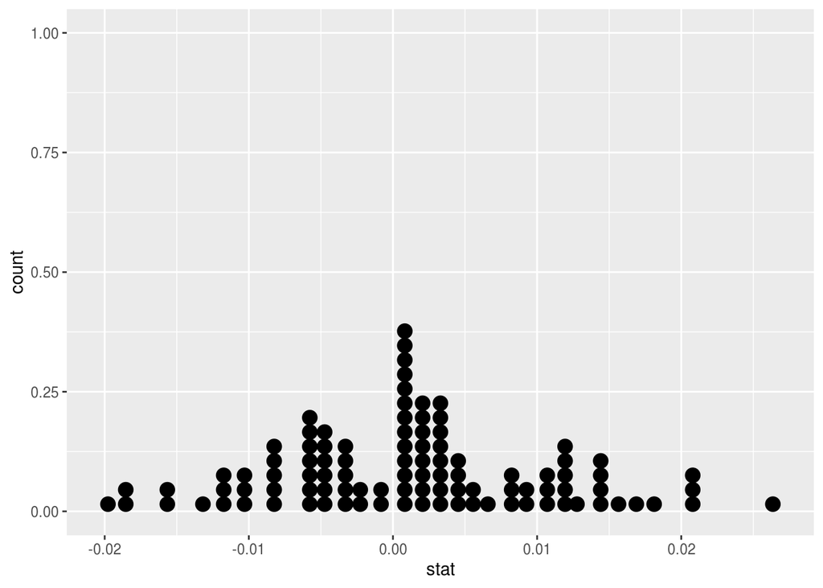

```r
# Exercise 2

# Perform 100 permutations
homeown_perm <- homes %>%
  specify(HomeOwn ~ Gender, success = "Own") %>%
  hypothesize(null = "independence") %>%
  generate(reps = 100, type = "permute") %>%
  calculate(stat = "diff in props", order = c("male", "female"))

# Dotplot of 100 permuted differences in proportions
ggplot(homeown_perm, aes(x = stat)) +
  geom_dotplot(binwidth = 0.001)
```

#### Randomization density

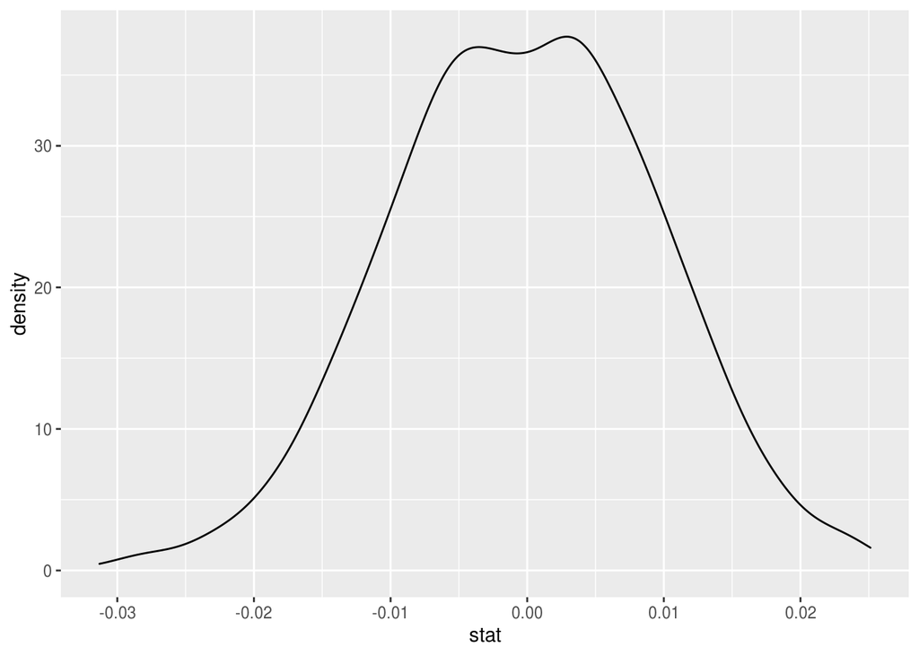

```r
# Perform 1000 permutations
homeown_perm <- homes %>%
  # Specify HomeOwn vs. Gender, with `"Own" as success
  specify(HomeOwn ~ Gender, success = "Own") %>%
  # Use a null hypothesis of independence
  hypothesize(null = "independence") %>%
  # Generate 1000 repetitions (by permutation)
  generate(reps = 1000, type = "permute") %>%
  # Calculate the difference in proportions (male then female)
  calculate("diff in props", order = c("male", "female"))

# Density plot of 1000 permuted differences in proportions
ggplot(homeown_perm, aes(x = stat)) +
  geom_density()
```

### Using the randomized distribution

VIDEO SUMMARY: The logic of statistical inference is to compare the observed statistic to the distribution of statistics that come from a null distribution. Each dot that’s randomly generated is from a different permutation of the data. The $H_0$ differences (the dots) to define the setting we are not interested in. The **“goal”** is to show that our observed data is not consistent with the differences generated. In order for the $H_A$ to be `TRUE`, we need out observed data to be different from the null differences.

#### Do the data come from the population?

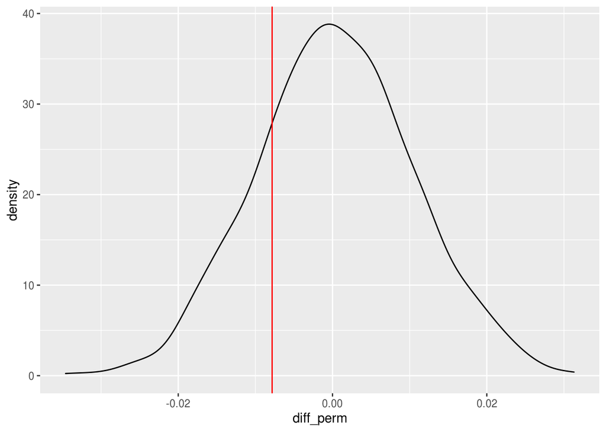

```r
homeown_perm <- homes %>%
  rep_sample_n(size = nrow(homes), reps = 1000) %>%
  mutate(own_perm = sample(HomeOwn)) %>%
  group_by(replicate, Gender) %>%
  summarize(prop_own_perm = mean(own_perm == "Own"),
            prop_own = mean(HomeOwn == "Own")) %>%
  summarize(diff_perm = diff(prop_own_perm),
            diff_orig = diff(prop_own))


# Plot permuted differences, diff_perm
ggplot(homeown_perm, aes(x = diff_perm)) +
  # Add a density layer
  geom_density() +
  # Add a vline layer with intercept diff_orig
  geom_vline(aes(xintercept = diff_orig), color = "red")
```

```r
# Compare permuted differences to observed difference
homeown_perm %>%
  summarize(n_perm_le_obs = sum(diff_perm <= diff_orig))
```

```
# A tibble: 1 x 1
  n_perm_le_obs
          <int>
1           218
```

#### What can you conclude?

CONCLUSION: We have learned that our data is consistent with the hypothesis of no difference in home ownership across gender.

#### The study conclusions

VIDEO SUMMARY: In the NHANES data, the observed statistic was consistent with the null statistic, that, there was no difference in home ownwership across gender. However, it does not mean that we know for sure that gender does not play a role. Statistical inference only allows us to reject null claims or fail to reject null claims. This process doesn’t not ensure certainty in either hypothesis stated.

Reject the $H_0$: There is sufficient evidence that the data are inconsistent with the $H_0$.

Fail to reject the $H_0$: There is no evidence that the data are inconsistent with the $H_0$.

### ② Completing a Randomization Test: Gender Discrimination

#### Example: gender discrimination

VIDEO SUMMARY: The data used is the influence of sex roles stereotypes on personnel decisions. 48 male bank supervisors were given personnel files and asked to judge whether the person should be promoted to a branch manager position. The files were all identitical except, 1/2 the files indicated whether a candidate was male or female. The data showed that 21 male candidates were promoted while 14 female candidates were promoted. The difference in promotions were shown by promotion rates. 87.5% of males were promotion and 58.3% of females were promoted.

If the data is shuffled so that gender and promotion are not linked, what chance differences are observed? The shuffling process breaks the relationship between gender and promotion so that we can understand the variability of differences in promotions assuming there is no connection between the 2 variables.

#### Example: Gender discrimination hypotheses

Which of the following null ($H_0$) and alternative ($H_A$) hypotheses are appropriate for the gender discrimination example described in the previous video?

$H_0:$ gender and promotion are unrelated variables

$H_A:$ men are more likely to be promoted

#### Summarizing gender discrimination

```r
# Create a contingency table summarizing the data
disc %>%
  count(sex, promote) # Count the rows by sex, promote
```

```
# A tibble: 4 x 3
  sex    promote          n
  <fct>  <fct>        <int>
1 male   not_promoted     3
2 male   promoted        21
3 female not_promoted    10
4 female promoted        14
```

```r
# Find proportion of each sex who were promoted
disc %>%
  # Group by sex
  group_by(sex) %>%
  # Calculate proportion promoted summary stat
  summarize(promoted_prop = mean(promote == "promoted"))
```

```
# A tibble: 2 x 2
  sex    promoted_prop
  <fct>          <dbl>
1 male           0.875
2 female         0.583
```

#### Step-by-step through the permutation

```r
# Replicate the entire data frame, permuting the promote variable
disc_perm <- disc %>%
  specify(promote ~ sex, success = "promoted") %>%
  hypothesize(null = "independence") %>%
  generate(reps = 5, type = "permute")

disc_perm %>%
  # Group by replicate
  group_by(replicate) %>%
  # Count per group
  count(promote)
```

```
# A tibble: 10 x 3
# Groups:   replicate [5]
   replicate promote          n
       <int> <fct>        <int>
 1         1 not_promoted    13
 2         1 promoted        35
 3         2 not_promoted    13
 4         2 promoted        35
 5         3 not_promoted    13
 6         3 promoted        35
 7         4 not_promoted    13
 8         4 promoted        35
 9         5 not_promoted    13
10         5 promoted        35
```

```r
disc_perm %>%
  # Calculate difference in proportion, male then female
  calculate(stat = "diff in props", order = c("male", "female"))
```

```
# A tibble: 5 x 2
  replicate    stat
      <int>   <dbl>
1         1 -0.0417
2         2 -0.0417
3         3  0.0417
4         4  0.0417
5         5 -0.0417
```

#### Randomizing gender discrimination

```r
# Exercise 1

# Calculate the observed difference in promotion rate
diff_orig <- disc %>%
  # Group by sex
  group_by(sex) %>%
  # Summarize to calculate fraction promoted
  summarize(prop_prom = mean(promote == "promoted")) %>%
  # Summarize to calculate difference
  summarize(stat = diff(prop_prom)) %>%
  pull()

# See the result
diff_orig <- diff_orig * -1
```

```r
# Exercise 2

# Create data frame of permuted differences in promotion rates
disc_perm <- disc %>%
  # Specify promote vs. sex
  specify(promote ~ sex, success = "promoted") %>%
  # Set null hypothesis as independence
  hypothesize(null = "independence") %>%
  # Generate 1000 permutations
  generate(reps = 1000, type = "permute") %>%
  # Calculate difference in proportions
  calculate(stat = "diff in props", order = c("male", "female"))
```

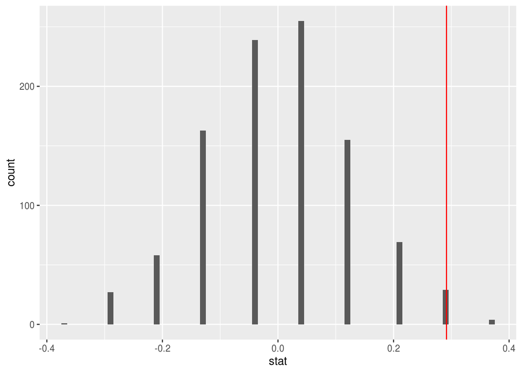

```r
# Exercise 3

# From previous steps
diff_orig <- disc %>%
  group_by(sex) %>%
  summarize(prop_prom = mean(promote == "promoted")) %>%
  summarize(stat = diff(prop_prom)) %>%
  pull()
disc_perm <- disc %>%
  specify(promote ~ sex, success = "promoted") %>%
  hypothesize(null = "independence") %>%
  generate(reps = 1000, type = "permute") %>%
  calculate(stat = "diff in props", order = c("male", "female"))
diff_orig <- diff_orig * -1

# Using permutation data, plot stat
ggplot(disc_perm, aes(x = stat)) +
  # Add a histogram layer
  geom_histogram(binwidth = 0.01) +
  # Add a vertical line at diff_orig
  geom_vline(aes(xintercept = diff_orig), color = "red")
```

#### Distribution of statistics

VIDEO SUMMARY: Before, we used the difference in proportions ($\widehat{p} - p$) to understand the difference between the null statistic and the observed statistic. Instead of looking at differences, we can use a ratio $\frac{\widehat{p}}{p}$ to explain whether the observed statistic is different from the values collected by the shuffling. We can calculate quantiles of the null statistics to measure how far the observed statistic is from the null values.

#### Reflecting on analysis

Based on the plot you created in the last exercise (displayed again here), which of the following seems like a reasonable conclusion about promotions?

**Answer**: In the population there is evidence that women are promoted at a different rate, but we cannot tell whether the difference is due to discrimination or something else.

#### Critical region

```r
disc_perm %>%
  summarize(
    # Find the 0.9 quantile of diff_perm's stat
    q.90 = quantile(stat, p = .90),
    # ... and the 0.95 quantile
    q.95 = quantile(stat, p = .95),
    # ... and the 0.99 quantile
    q.99 = quantile(stat, p = .99)
  )
```

```
# A tibble: 1 x 3
   q.90  q.95  q.99
  <dbl> <dbl> <dbl>
1 0.208 0.208 0.292
```

#### Two-sided critical region

```r
# Use disc_perm
disc_perm %>%
  # ... to calculate summary stats
  summarize(
    # Find the 0.01 quantile of stat
    q.01 = quantile(stat, p = .01),
    # ... and 0.05
    q.05 = quantile(stat, p = .05),
    # ... and 0.1
    q.10 = quantile(stat, p = .10)
  )
```

```
# A tibble: 1 x 3
    q.01   q.05   q.10
   <dbl>  <dbl>  <dbl>
1 -0.292 -0.208 -0.125
```

#### Why 0.05?

VIDEO SUMMARY: Cutoff values allow you to know how big or small the observed statistic should be in order to reject the null hypothesis. The cutoff point of 0.05 is somewhat random, but it has been used historically in science and is intuitive. In 1929, RA Fisher wrote a that result should be judged significant if it was not likely to happen by chance more than once in 20 trials. He also stated that the value is convenient. The test of significance should be used to determine which research to replicate and which to not. Any given level of significance is personal and subjective but not meaningless. The 5% significance level indicates a degree of skepticism and is the significant results that should lead to further research on a particular topic.

#### How does the sample size affect results?

Notice that the observed difference of 0.2917 is in the extreme right tail of the permuted differences. If the **sample was ten times larger** but the sample statistic was exactly the same (i.e. 0.2917), how would the distribution of permuted differences change? Complete the following sentence.

CONCLUSION: The statistic of 0.2917 would **be much farther to the right of the permuted differences (completely off of the distribution).**

#### Sample size in randomization distribution

```r
# Tabulate the small dataset
disc_small %>%
  # Select sex and promote
  count(sex, promote)
```

```
# A tibble: 4 x 3
  sex    promote          n
  <fct>  <fct>        <int>
1 female not_promoted     3
2 female promoted         5
3 male   not_promoted     1
4 male   promoted         7
```

```r
disc_perm_small <- disc_small %>%
  specify(promote ~ sex, success = "promoted") %>%
  hypothesize(null = "independence") %>%
  generate(reps = 1000, type = "permute") %>%
  calculate(stat = "diff in props", order = c("male", "female"))

diff_orig_small <- disc_small %>%
  group_by(sex) %>%
  summarize(prop_prom = mean(promote == "promoted")) %>%
  summarize(stat = diff(prop_prom)) %>%
  pull()

# Do the same for disc_big
disc_big %>%
  count(sex, promote)
```

```
# A tibble: 4 x 3
  sex    promote          n
  <fct>  <fct>        <int>
1 female not_promoted   100
2 female promoted       140
3 male   not_promoted    30
4 male   promoted       210
```

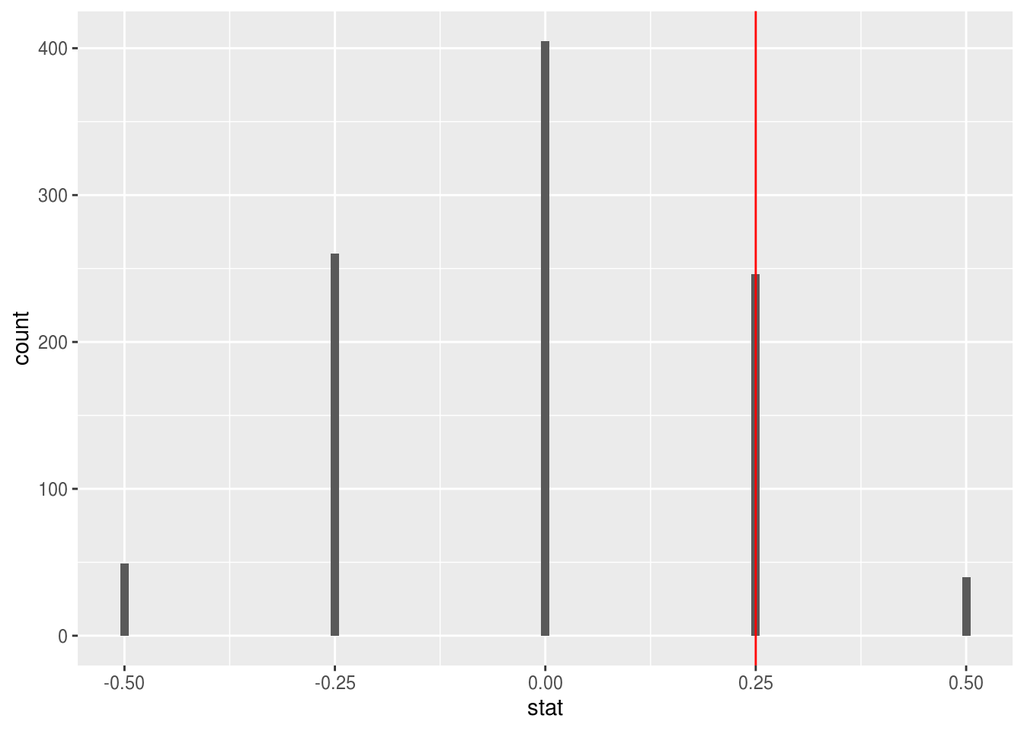

```r
disc_perm_big <- disc_big %>%
  specify(promote ~ sex, success = "promoted") %>%
  hypothesize(null = "independence") %>%
  generate(reps = 1000, type = "permute") %>%
  calculate(stat = "diff in props", order = c("male", "female"))

diff_orig_big <- disc_big %>%
  group_by(sex) %>%
  summarize(prop_prom = mean(promote == "promoted")) %>%
  summarize(stat = diff(prop_prom)) %>%
  pull()

# Using disc_perm_small, plot stat
ggplot(disc_perm_small, aes(x = stat)) +
  # Add a histogram layer with binwidth 0.01
  geom_histogram(binwidth = .01) +
  # Add a vline layer, crossing x-axis at diff_orig_small
  geom_vline(aes(xintercept = diff_orig_small), color = "red")
```

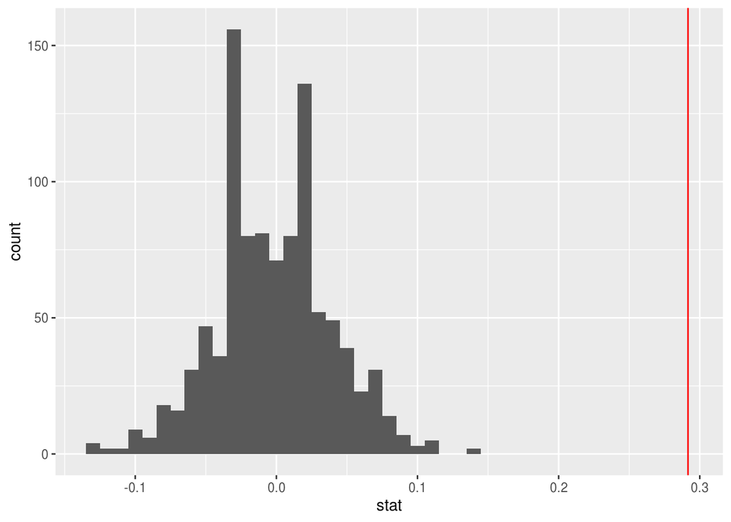

```r
# Swap the dataset to disc_perm_big
ggplot(disc_perm_big, aes(x = stat)) +
  geom_histogram(binwidth = 0.01) +
  # Change the x-axis intercept to diff_orig_big
  geom_vline(aes(xintercept = diff_orig_big), color = "red")
```

#### Sample size for critical region

```r
calc_upper_quantiles <- function(dataset) {
  dataset %>%
    summarize(
      q.90 = quantile(stat, p = 0.90),
      q.95 = quantile(stat, p = 0.95),
      q.99 = quantile(stat, p = 0.99)
    )
}

# Recall the quantiles associated with the original dataset
calc_upper_quantiles(disc_perm)
```

```
# A tibble: 1 x 3
   q.90  q.95  q.99
  <dbl> <dbl> <dbl>
1 0.208 0.208 0.292
```

```r
# Calculate the quantiles associated with the small dataset
calc_upper_quantiles(disc_perm_small)
```

```
# A tibble: 1 x 3
   q.90  q.95  q.99
  <dbl> <dbl> <dbl>
1  0.25  0.25   0.5
```

```r
# Calculate the quantiles associated with the big dataset
calc_upper_quantiles(disc_perm_big)
```

```
# A tibble: 1 x 3
    q.90   q.95   q.99
   <dbl>  <dbl>  <dbl>
1 0.0500 0.0667 0.0917
```

#### What is a p-value?

VIDEO SUMMARY: To get around the sometimes reject problem, we quantify the degree to which the data do not agree with the null distribution. P-value is the probability of observing data as or more extreme than what we actually got given that the null hypothesis is true.

#### Calculating the p-values

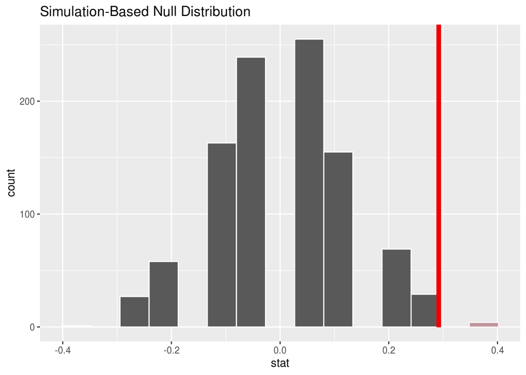

```r
# Visualize and calculate the p-value for the original dataset
disc_perm %>%
  visualize(obs_stat = diff_orig, direction = "greater")
```

```r
disc_perm %>%
  get_p_value(obs_stat = diff_orig, direction = "greater")
```

```
# A tibble: 1 x 1
  p_value
    <dbl>
1   0.033
```

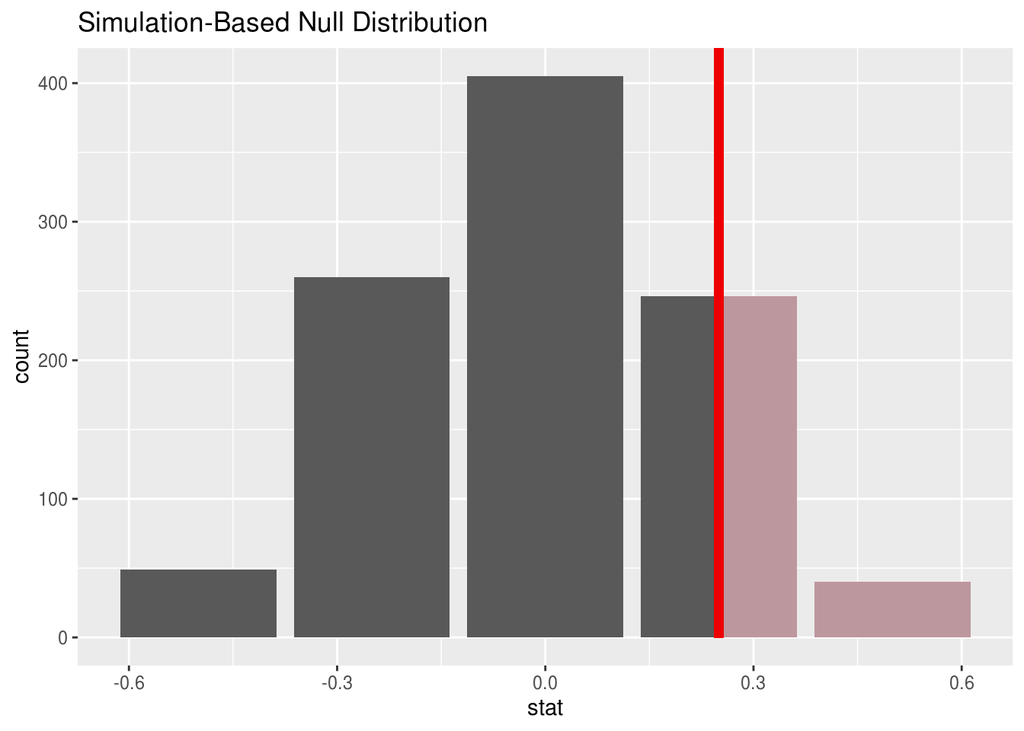

```r
# Visualize and calculate the p-value for the small dataset
disc_perm_small %>%
  visualize(obs_stat = diff_orig_small, direction = "greater")
```

```r
disc_perm_small %>%
  get_p_value(obs_stat = diff_orig_small, direction = "greater")
```

```
# A tibble: 1 x 1
  p_value
    <dbl>
1   0.286
```

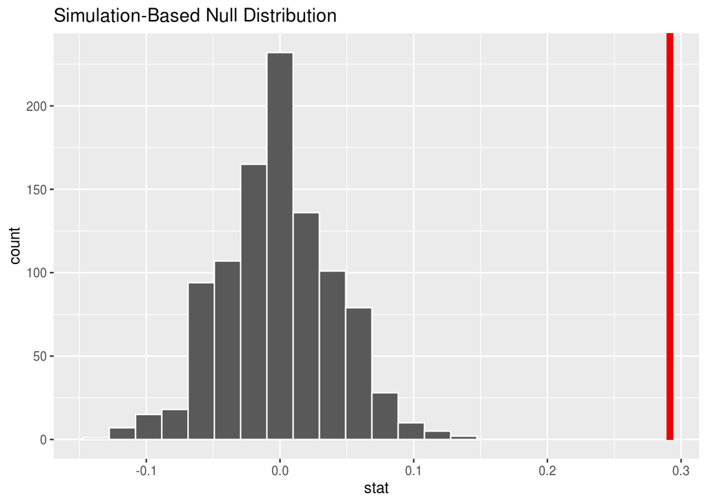

```r
# Visualize and calculate the p-value for the big dataset
disc_perm_big %>%
  visualize(obs_stat = diff_orig_big, direction = "greater")
```

```r
disc_perm_big %>%
  get_p_value(obs_stat = diff_orig_big, direction = "greater")
```

```
# A tibble: 1 x 1
  p_value
    <dbl>
1       0
```

#### Practice calculating p-values

```r
# Exercise 1

# Recall the original data
disc %>%
  count(sex, promote)
```

```
# A tibble: 4 x 3
  sex    promote          n
  <fct>  <fct>        <int>
1 male   not_promoted     3
2 male   promoted        21
3 female not_promoted    10
4 female promoted        14
```

```r
# Tabulate the new data
disc_new %>%
  count(sex, promote)
```

```
# A tibble: 4 x 3
  sex    promote          n
  <fct>  <fct>        <int>
1 female not_promoted     7
2 female promoted        17
3 male   not_promoted     6
4 male   promoted        18
```

```r
disc_perm_new <- disc_new %>%
  specify(promote ~ sex, success = "promoted") %>%
  hypothesize(null = "independence") %>%
  generate(reps = 1000, type = "permute") %>%
  calculate(stat = "diff in props", order = c("male", "female"))

diff_orig_new <- disc_new %>%
  group_by(sex) %>%
  summarize(prop_prom = mean(promote == "promoted")) %>%
  summarize(stat = diff(prop_prom)) %>%
  pull()
```

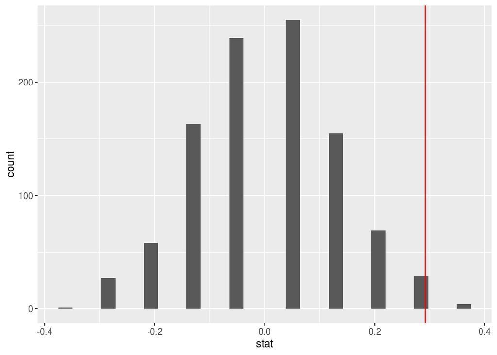

```r
# Exercise 2

# Recall the distribution of the original permuted differences
ggplot(disc_perm, aes(x = stat)) +
  geom_histogram() +
  geom_vline(aes(xintercept = diff_orig), color = "red")
```

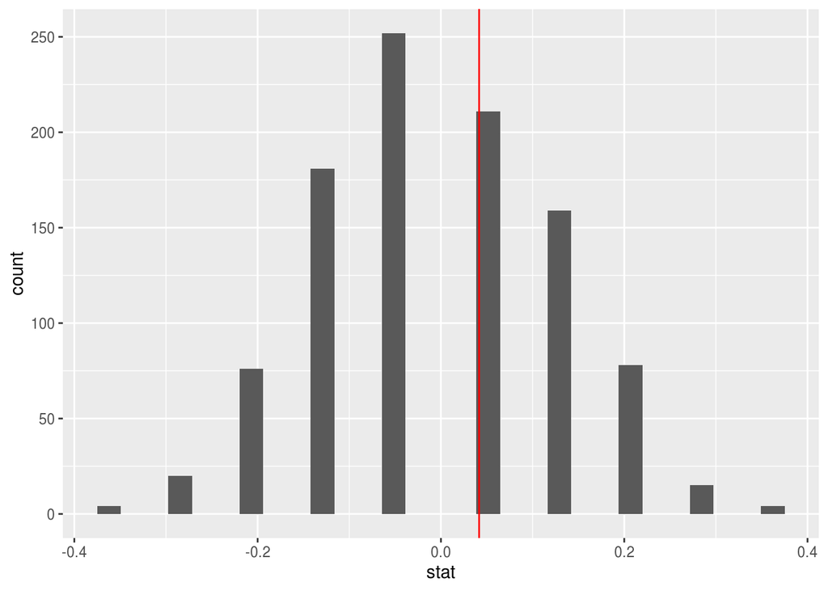

```r
# Plot the distribution of the new permuted differences
ggplot(disc_perm_new, aes(x = stat)) +
  geom_histogram() +
  geom_vline(aes(xintercept = diff_orig_new), color = "red")
```

```r
# Exercise 3

# Recall the p-value from the original data
disc_perm %>%
  summarize(p_value = mean(diff_orig <= stat))
```

```
# A tibble: 1 x 1
  p_value
    <dbl>
1   0.033
```

```r
# Find the p-value from the new data
disc_perm_new %>%
  summarize(p_value = mean(diff_orig_new <= stat))
```

```
# A tibble: 1 x 1
  p_value
    <dbl>
1   0.467
```

#### Calculating two-sided p-values

```r
disc_perm %>%
  summarize(p_value =  2 * mean(diff_orig <= stat))
```

```
# A tibble: 1 x 1
  p_value
    <dbl>
1   0.066
```

#### Summary of gender discrimination

The study was randomized. There was nothing systematically different about the two groups other than the names. Any differnce in promotion rates is due to the gender of the applicant. We can infer a causal connection between being male and getting a promotion.

The results are not generalizable because the group of managers were at a training session and does not represent banks across the nation.

### ③ Hypothesis Testing Errors: Opportunity Cost

#### Example: opportunity cost

VIDEO SUMMARY: Looking at data from a study on opportunity costs. Researchers investigated whether reminding students about spending money will make it less likely for them to spend money on a DVD video. 75 students were randomly assigned to the control group and were presented with 2 options: a) buy the entertaining video or b) not buy the entertaining video. 75 students were randomly assigned to the treatment group and were also assigned 2 options: a) buy the entertaining video or b) not buy the entertaining video and keep the $14.99 for other purchases.

$H_0$: Reminding students will have no impact on their spending choices

$H_A$: Reminding students will reduce the chance they continue with a purchase

In the control group, 74.67% of students bought the DVD while only 54.67% of students in the treatment group bought the DVD.

#### Summarizing opportunity cost (1)

```r
# Tabulate the data
opportunity %>%
  count(decision, group)
```

```
# A tibble: 4 x 3
  decision group         n
  <chr>    <chr>     <int>
1 buyDVD   control      56
2 buyDVD   treatment    41
3 nobuyDVD control      19
4 nobuyDVD treatment    34
```

```r
# Find the proportion who bought the DVD in each group
opportunity %>%
  group_by(group) %>%
  summarize(buy_prop = mean(decision == "buyDVD"))
```

```
# A tibble: 2 x 2
  group     buy_prop
  <chr>        <dbl>
1 control      0.747
2 treatment    0.547
```

#### Plotting opportunity cost

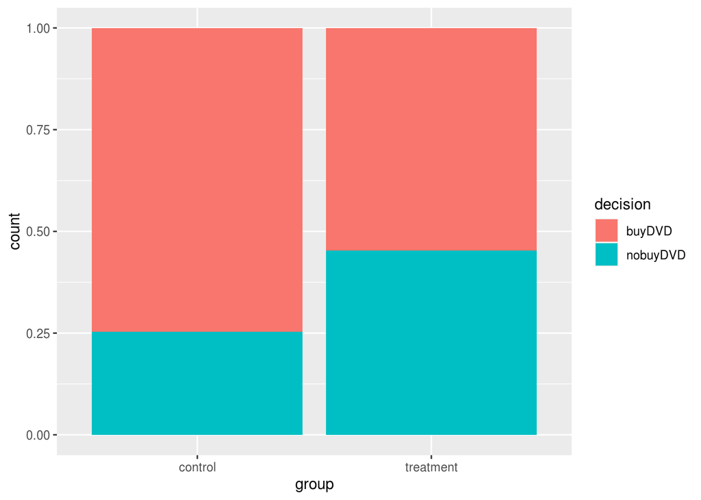

```r
# Plot group, filled by decision
ggplot(opportunity, aes(x = group, fill = decision)) +
  # Add a bar layer, with position "fill"
  geom_bar(position = "fill")
```

#### Randomizing opportunity cost

```r
# Exercise 1

# Calculate the observed difference in purchase rate
diff_obs <- opportunity %>%
  # Group by group
  group_by(group) %>%
  # Calculate proportion deciding to buy a DVD
  summarize(prop_buy = mean(decision == "buyDVD")) %>%
  # Calculate difference between groups
  summarize(stat = diff(prop_buy)) %>%
  pull()

# Review the result
diff_obs
```

```
[1] -0.2
```

```r
# Exercise 2

# Create data frame of permuted differences in purchase rates
opp_perm <- opportunity %>%
  # Specify decision vs. group, where success is buying a DVD
  specify(decision ~ group, success = "buyDVD") %>%
  # Set the null hypothesis to independence
  hypothesize(null = "independence") %>%
  # Generate 1000 reps of type permute
  generate(reps = 1000, type = "permute") %>%
  # Calculate the summary stat difference in proportions
  calculate(stat = "diff in props", order = c("treatment", "control"))

# Review the result
opp_perm
```

```
# A tibble: 1,000 x 2
   replicate    stat
       <int>   <dbl>
 1         1 -0.0133
 2         2  0.0133
 3         3  0.0400
 4         4  0.0400
 5         5  0.0667
 6         6  0.0667
 7         7  0.0667
 8         8 -0.0133
 9         9 -0.0933
10        10  0.0133
# … with 990 more rows
```

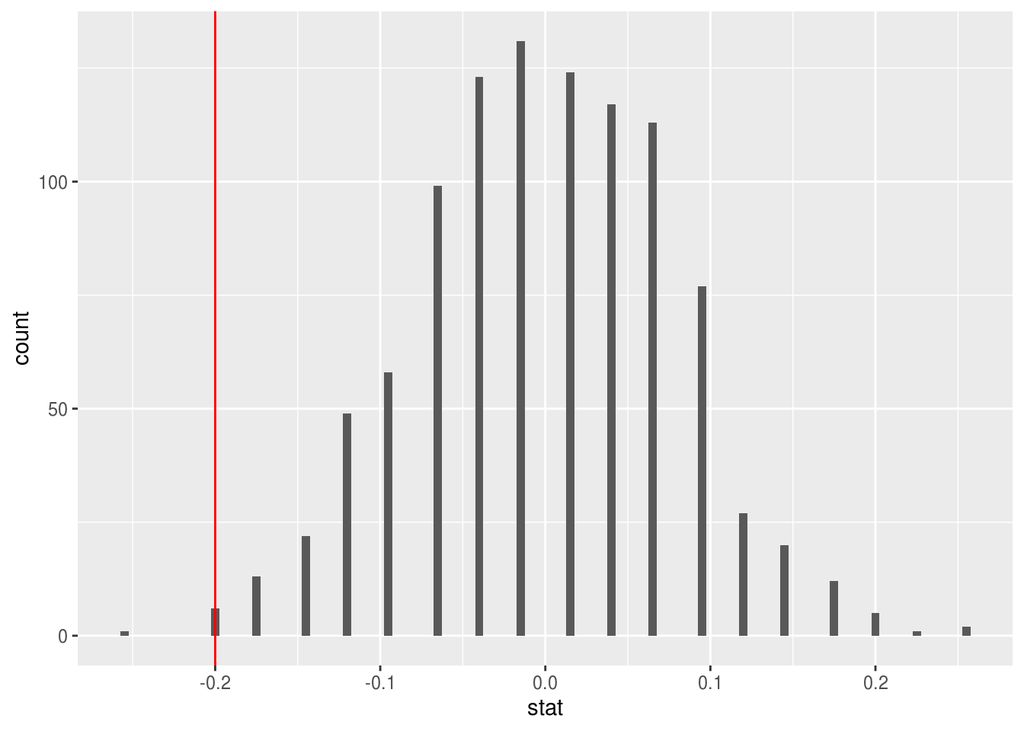

```r
# Exercise 3

# From previous steps
diff_obs <- opportunity %>%
  group_by(group) %>%
  summarize(prop_buy = mean(decision == "buyDVD")) %>%
  summarize(stat = diff(prop_buy)) %>%
  pull()
opp_perm <- opportunity %>%
  specify(decision ~ group, success = "buyDVD") %>%
  hypothesize(null = "independence") %>%
  generate(reps = 1000, type = "permute") %>%
  calculate(stat = "diff in props", order = c("treatment", "control"))

# Using the permuation data, plot stat
ggplot(opp_perm, aes(x = stat)) +
  # Add a histogram layer with binwidth 0.005
  geom_histogram(binwidth = 0.005) +
  # Add a vline layer with intercept diff_obs
  geom_vline(aes(xintercept = diff_obs), color = "red")
```

#### Summarizing opportunity cost (2)

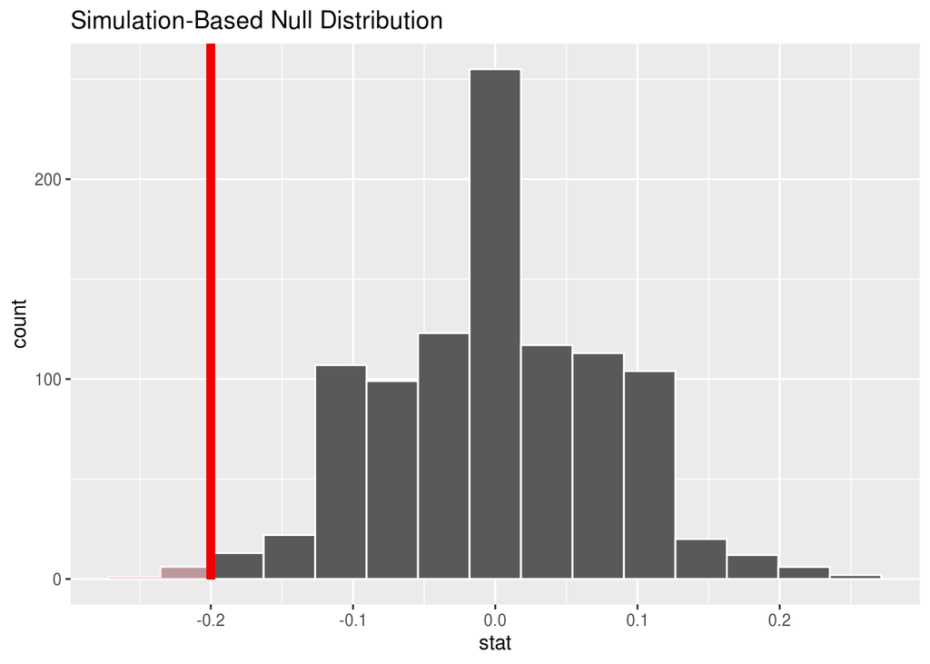

```r
# Visualize the statistic
opp_perm %>%
  visualize(obs_stat = diff_obs, direction = "less")
```

```r
# Calculate the p-value using `get_p_value`
opp_perm %>%
  get_p_value(obs_stat = diff_obs, direction = "less")
```

```
# A tibble: 1 x 1
  p_value
    <dbl>
1   0.007
```

```r
# Calculate the p-value using `summarize`
opp_perm %>%
  summarize(p_value = mean(stat <= diff_obs))
```

```
# A tibble: 1 x 1
  p_value
    <dbl>
1   0.007
```

#### Opportunity cost conclusion

CONCLUSION: Reminding them causes them to be less likely to buy the DVD

#### Errors and their consequences

VIDEO SUMMARY: It seems that reminding students to save has a causal impact on the likelihood that they will buy a DVD. That is because the observed difference is inconsistent with the null differences. There’s a possibility that our conclusion is wrong. There are 2 test conclusions (reject the $H_0$ or fail to reject the $H_0$) and 2 truths (the $H_0$ is true or the $H_A$ is true).

Type I Error: false positive (we reject the $H_0$ but the $H_0$ is true)

Type II Error: false negative (we fail to reject the $H_0$ but the $H_A$ is true)

#### Different choice of error rate

Consider again a situation where the task is to differentiate the proportion of successes across two different groups. What decision should be made if the goal is to never make a type II error (false negative)?

DECISION: Always claim there is a difference in proportions

#### Errors for two-sided hypotheses

What are type I (false positive) and type II (false negative) errors for the two-sided hypotheses related to the opportunity costs example?

Type I Error: There is not a difference in proportions, but the observed difference is big enough to indicate that the proportions are different.

Type II Error: There is a difference in proportions, but the observed difference is not large enough to indicate that the proportions are different.

#### p-value for two-sided hypotheses: opportunity costs

```r
# Calculate the two-sided p-value
opp_perm %>%
  summarize(p_value = 2 * mean(stat <= diff_obs))
```

```
# A tibble: 1 x 1
  p_value
    <dbl>
1   0.014
```

#### Summary of opportunity costs

VIDEO SUMMARY: The difference in observed proportions is not consistent with the null hypothesis. Only 7 of the 1000 permutations were smaller than the observed data value. The study was randomized and nothing was systematically different about participants in treatment and control groups. Any difference in buying rates is due to the options given (being reminded to save). This study, however, cannot be generalized to the population because the participants were students. In order for it to be generalizable, more information about the students need to be collected so we can figure out who they represent.

### ④ Confidence Intervals

#### Parameters and confidence intervals

VIDEO SUMMARY: What if the research question is one of estimation as opposed to comparison? Hypothesis testing is used for comparison research questions while confidence intervals are used for estimation research questions.

Before understanding how confidence intervals work, we need to know what parameters are. A parameter is a numerical value from the population. A confidence interval is a range of numbers that (hopefully) captures the true parameter value. The **goal** in creating a confidence interval is to calculate a range of possible values for the parameter of interest.

#### What is the parameter?

Before investigating the sampling variability, what is the population parameter of interest?

**PARAMETER**: The proportion of all voters in your town who will vote for Candidate X on election day.

#### Hypothesis test or confidence interval?

A university is trying to determine whether parking is a problem on its campus. The student newspaper contacts a random sample of 200 students and asks whether or not they are frustrated with the parking situation. They want to estimate the proportion of students at the college who are frustrated with the parking situation.

In this setting, which is more appropriate, a hypothesis test or a confidence interval?

**CHOICE**: Confidence interval because the goal is to estimate a population parameter

#### Bootstrapping

VIDEO SUMMARY: With hypothesis testing, it is important to understand how samples from a null population vary. $\widehat{p}$: **statistic**, proportion of successes in a **sample**. $p$: **parameter**, proportion of successes in a **population**. With confidence intervals, there is no null population. We need to understand how samples from the population of interest vary. Bootstrapping is a method that allows us to estimate the distance from a statistic to the parameter. Bootstrapping repeatedly samples from a sample of a population. Each time we resample the data are sampled from the original sampled data with replacement. The bootstrap statistic is called $\widehat{p}^*$ which is the proportion of successes in the resample. It provides an excellent appxomixation of the SE. The standard error describes how the statistic varies around the parameter. The SE is key to building a confidence interval.

#### Resampling from a sample

```r
# Exercise 1

# Compute p-hat for each poll
ex1_props <- all_polls %>%
  # Group by poll
  group_by(poll) %>%
  # Calculate proportion of yes votes
  summarize(stat = mean(vote == "yes"))

# Review the result
ex1_props
```

```
# A tibble: 1,000 x 2
    poll  stat
   <int> <dbl>
 1     1 0.7
 2     2 0.667
 3     3 0.633
 4     4 0.633
 5     5 0.4
 6     6 0.6
 7     7 0.5
 8     8 0.533
 9     9 0.567
10    10 0.567
# … with 990 more rows
```

```r
# Exercise 2

# Select one poll from which to resample
one_poll <- all_polls %>%
  # Filter for the first poll
  filter(poll == 1) %>%
  # Select vote
  select(vote)

# Compute p-hat* for each resampled poll
ex2_props <- one_poll %>%
  # Specify vote as the response, where yes means success
  specify(response = vote, success = "yes") %>%
  # Generate 1000 reps of type bootstrap
  generate(reps = 1000, type = "bootstrap") %>%
  # Calculate the summary stat "prop"
  calculate(stat = "prop")
```

```r
# Exercise 3

# From previous steps
ex1_props <- all_polls %>%
  group_by(poll) %>%
  summarize(stat = mean(vote == "yes"))
ex2_props <- all_polls %>%
  filter(poll == 1) %>%
  select(vote) %>%
  specify(response = vote, success = "yes") %>%
  generate(reps = 1000, type = "bootstrap") %>%
  calculate(stat = "prop")

# Calculate variability of p-hat
ex1_props %>%
  summarize(variability = sd(stat))
```

```
# A tibble: 1 x 1
  variability
        <dbl>
1      0.0868
```

```r
# Calculate variability of p-hat*
ex2_props %>%
  summarize(variability = sd(stat))
```

```
# A tibble: 1 x 1
  variability
        <dbl>
1      0.0809
```

#### Visualizing the variability of p-hat

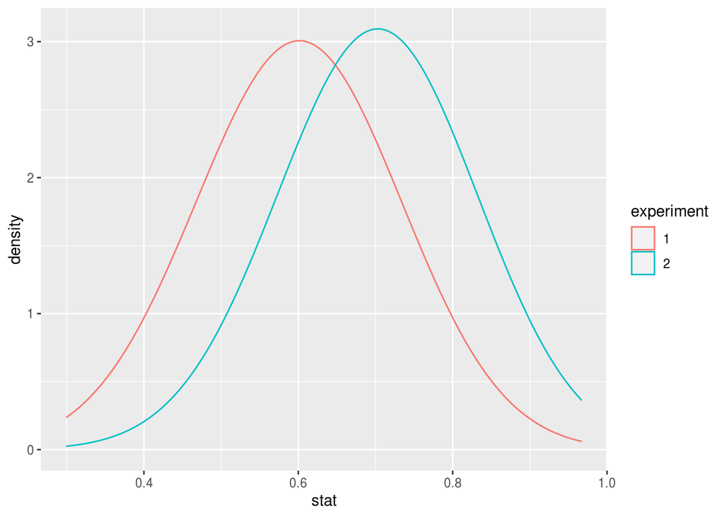

```r
# Combine data from both experiments
both_ex_props <- bind_rows(ex1_props, ex2_props, .id = "experiment")

# Using both_ex_props, plot stat colored by experiment
ggplot(both_ex_props, aes(stat, color = experiment)) +
  # Add a density layer with bandwidth 0.1
  geom_density(bw = 0.1)
```

#### Always resample the original number of observations

In the bootstrap examples, exactly 30 observations have been repeatedly resampled from the original sample. The choice of 30 was given because the original sample had 30 observations. If we had resampled 3 observations instead, the resampled $p^*$ value could have ranged from 0 to 1 (producing a much larger $SE(p^*)$ than desired). If we had resampled 300 observations instead, the resampled $p^*$ value would have been close to the same number each time (producing a much smaller $SE(p^*)$ than desired).

Generally, if $n$ represents the size of the original sample, how many observations should we resample with replacement when bootstrapping?

**HOW MANY OBSERVATIONS**: Resample exactly $n$ observations because then the variability of $p^*$ will be most similar/representative of the original sampling process.

#### Variability in p-hat

VIDEO SUMMARY: We won’t know how far the statistic is from the parameter just by looking at the sample of data. The variability of the $\widehat{p}$ statistics gives a measure for how far apart any given observed $\widehat{p}$ and the parameter are expected to be. With bootstrapping, or resampling, the same # of observations as were in the original sample provided approximately the same SE as sampling many $\widehat{p}$ values from the population. The SE is measured by the width of the distribution. We can use the value of the SE to count the number of sampled $\widehat{p}$s which are close to the parameter. Because the distribution of $\widehat{p}$ values is symmetric and bellshaped, roughly 95% of samples will produce $\widehat{p}$ that are within 2 SE of the center.

#### Empirical Rule

```r
# Proportion of yes votes by poll
props <- all_polls %>%
  group_by(poll) %>%
  summarize(prop_yes = mean(vote == "yes"))

# The true population proportion of yes votes
true_prop_yes <- 0.6

# Proportion of polls within 2SE
props %>%
  # Add column: is prop_yes in 2SE of 0.6
  mutate(is_in_conf_int = abs(prop_yes - true_prop_yes) < 2 * sd(prop_yes)) %>%
  # Calculate  proportion in conf int
  summarize(prop_in_conf_int = mean(is_in_conf_int))
```

```
# A tibble: 1 x 1
  prop_in_conf_int
             <dbl>
1            0.966
```

#### Bootstrap t-confidence interval

```r
# From previous exercises
one_poll <- all_polls %>%
  filter(poll == 1) %>%
  select(vote)
one_poll_boot <- one_poll %>%
  specify(response = vote, success = "yes") %>%
  generate(reps = 1000, type = "bootstrap") %>%
  calculate(stat = "prop")

p_hat <- one_poll %>%
  # Calculate proportion of yes votes
  summarize(stat = mean(vote == "yes")) %>%
  pull()

# Create an interval of plausible values
one_poll_boot %>%
  summarize(
    # Lower bound is p_hat minus 2 std errs
    lower = p_hat - 2 * sd(stat),
    # Upper bound is p_hat plus 2 std errs
    upper = p_hat + 2 * sd(stat)
  )
```

```
# A tibble: 1 x 2
  lower upper
  <dbl> <dbl>
1 0.536 0.864
```

#### Bootstrap percentile interval

```r
# From previous exercise: bootstrap t-confidence interval
one_poll_boot %>%
  summarize(
    lower = p_hat - 2 * sd(stat),
    upper = p_hat + 2 * sd(stat)
  )
```

```
# A tibble: 1 x 2
  lower upper
  <dbl> <dbl>
1 0.536 0.864
```

```r
# Manually calculate a 95% percentile interval
one_poll_boot %>%
  summarize(
    lower = quantile(stat, 0.025),
    upper = quantile(stat, 0.975)
  )
```

```
# A tibble: 1 x 2
  lower upper
  <dbl> <dbl>
1 0.533 0.867
```

```r
# From previous step
one_poll_boot %>%
  summarize(
    lower = quantile(stat, 0.025),
    upper = quantile(stat, 0.975)
  )
```

```
# A tibble: 1 x 2
  lower upper
  <dbl> <dbl>
1 0.533 0.867
```

```r
# Calculate the same interval, more conveniently
percentile_ci <- one_poll_boot %>%
  get_confidence_interval(level = .95)

# Review the value
percentile_ci
```

```
# A tibble: 1 x 2
  `2.5%` `97.5%`
   <dbl>   <dbl>
1  0.533   0.867
```

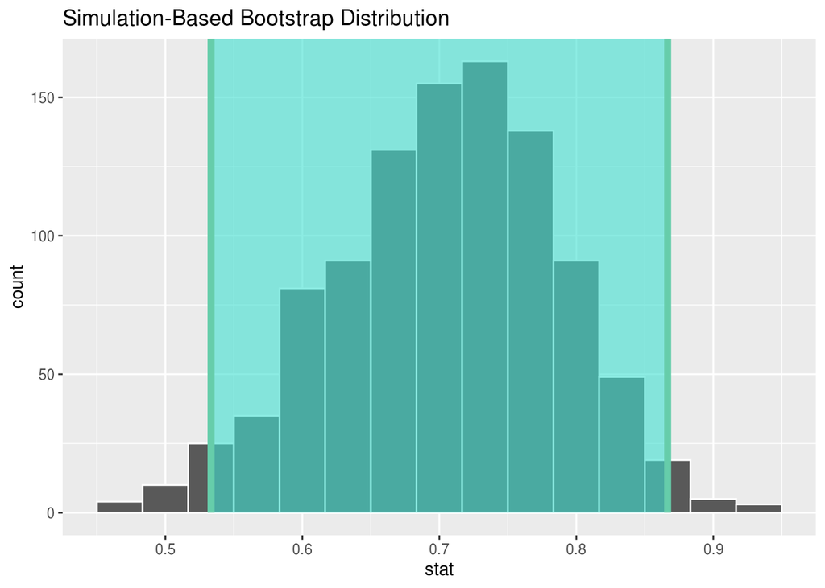

```r
# From previous step
percentile_ci <- one_poll_boot %>%
  get_confidence_interval(level = 0.95)

one_poll_boot %>%
  # Visualize in-between the endpoints given by percentile_ci
  visualize(endpoints = percentile_ci, direction = "between")
```

#### Interpreting CIs and technical conditions

VIDEO SUMMARY: The goal is to find an interval estimate of the parameter the true proportion of the population when the only information we have is the sample. Because we don’t know whether the sample collect actually contains the true parameter, we interpret the interval using a confidence percentage. “We are 95% confident that the true proportion of…” We can use bootstrapping so long as it passes these technical conditions: 1) Sampling distribution of the statistic is reasonably symmetric and bell-shaped. 2) Sample size is reasonably large.

#### Sample size effects on bootstrap CIs

```r
calc_t_conf_int <- function(resampled_dataset) {
  resampled_dataset %>%
    summarize(
      lower = p_hat - 2 * sd(stat),
      upper = p_hat + 2 * sd(stat)
    )
}

# Find the bootstrap t-confidence interval for 30 resamples
one_poll_boot_30 <- one_poll %>%
  specify(response = vote, success = "yes") %>%
  generate(reps = 30, type = "bootstrap") %>%
  calculate(stat = "prop")
calc_t_conf_int(one_poll_boot_30)
```

```
# A tibble: 1 x 2
  lower upper
  <dbl> <dbl>
1 0.505 0.895
```

```r
# ... and for 300 resamples
one_poll_boot_300 <- one_poll %>%
  specify(response = vote, success = "yes") %>%
  generate(reps = 300, type = "bootstrap") %>%
  calculate(stat = "prop")
calc_t_conf_int(one_poll_boot_300)
```

```
# A tibble: 1 x 2
  lower upper
  <dbl> <dbl>
1 0.526 0.874
```

```r
# ... and for 3 resamples
one_poll_boot_3 <- one_poll %>%
  specify(response = vote, success = "yes") %>%
  generate(reps = 3, type = "bootstrap") %>%
  calculate(stat = "prop")
calc_t_conf_int(one_poll_boot_3)
```

```
# A tibble: 1 x 2
  lower upper
  <dbl> <dbl>
1 0.585 0.815
```

#### Sample proportion value effects on bootstrap CIs

```r
calc_p_hat <- function(dataset) {
  dataset %>%
    summarize(stat = mean(vote == "yes")) %>%
    pull()
}
calc_t_conf_int <- function(resampled_dataset, p_hat) {
  resampled_dataset %>%
    summarize(
      lower = p_hat - 2 * sd(stat),
      upper = p_hat + 2 * sd(stat)
    )
}

# Find proportion of yes votes from original population
p_hat <- calc_p_hat(one_poll)

# Review the value
p_hat
```

```
[1] 0.7
```

```r
# Calculate bootstrap t-confidence interval (original 0.6 param)
calc_t_conf_int(one_poll_boot, p_hat)
```

```
# A tibble: 1 x 2
  lower upper
  <dbl> <dbl>
1 0.536 0.864
```

```r
# Find proportion of yes votes from new population
# Proportion of yes votes by poll
one_poll_0.8 <- all_polls %>%
  group_by(poll) %>%
  summarize(prop_yes = mean(vote == "yes"))

# The true population proportion of yes votes
true_prop_yes <- 0.8

# Proportion of polls within 2SE
one_poll_0.8 %>%
  # Add column: is prop_yes in 2SE of 0.6
  mutate(is_in_conf_int = abs(prop_yes - true_prop_yes) < 2 * sd(prop_yes)) %>%
  # Calculate  proportion in conf int
  summarize(prop_in_conf_int = mean(is_in_conf_int))
```

```
# A tibble: 1 x 1
  prop_in_conf_int
             <dbl>
1            0.428
```

```r
###

one_poll_0.8 <- all_polls %>%
  filter(poll == 1) %>%
  select(vote)

p_hat_0.8 <- calc_p_hat(one_poll_0.8)

# Review the value
p_hat_0.8
```

```
[1] 0.7
```

```r
# Calculate the bootstrap t-confidence interval (new 0.8 param)
one_poll_boot_0.8 <- one_poll_0.8 %>%
  specify(response = vote, success = "yes") %>%
  generate(reps = 1000, type = "bootstrap") %>%
  calculate(stat = "prop")

calc_t_conf_int(one_poll_boot_0.8, p_hat_0.8)
```

```
# A tibble: 1 x 2
  lower upper
  <dbl> <dbl>
1 0.532 0.868
```

#### Percentile effects on bootstrap CIs

```r
# Calculate a 95% bootstrap percentile interval
one_poll_boot %>%
  get_confidence_interval(level = 0.95)
```

```
# A tibble: 1 x 2
  `2.5%` `97.5%`
   <dbl>   <dbl>
1  0.533   0.867
```

```r
# Calculate a 99% bootstrap percentile interval
one_poll_boot %>%
  get_confidence_interval(level = 0.99)
```

```
# A tibble: 1 x 2
  `0.5%` `99.5%`
   <dbl>   <dbl>
1    0.5     0.9
```

```r
# Calculate a 90% bootstrap percentile interval
one_poll_boot %>%
  get_confidence_interval(level = 0.90)
```

```
# A tibble: 1 x 2
   `5%` `95%`
  <dbl> <dbl>
1 0.567 0.833
```

```r
# Plot ci_endpoints vs. ci_percent to compare the intervals
#ggplot(conf_int_data, aes(ci_percent, ci_endpoints)) +
  # Add a line layer
 # geom_line()
```

#### Summary of statistical inference

VIDEO SUMMARY: In this course, we focused on making claims about a population using information from a sample of data. Hypothesis testing is used to test a particular claim about the population. The claim you want to refute is the null hypothesis. The claim you want to be true is the alternative hypothesis. Estimation is used to understand the value of a population parameter. Using measures of variablility of the statistic we can estimate how far p-hat is from the true proportion. Bootstrapping, or resampling, can measure the variablility of p-hat.